# Data Exploration with R

```r
knitr::opts_knit$set(root.dir = rprojroot::find_rstudio_root_file())
```

# Getting started

## Loading packages

```r
library(lsr)
library(Hmisc)
library(car)
library(DescTools)
library(psych)
library(tidyverse)
library(haven)
library(broom)
```

## Loading data

### From the project folder

```r
## CSV ##
affect.data <- read_csv("./data/affect.data.csv")
## SAV ##
# affect.data <- read_sav("./data/affect.data.sav")
```

### From OSF

```r
## CSV ##
# affect.data <- read_csv("https://osf.io/ahda9/download")
## SAV ##
# affect.data <- read_sav("https://osf.io/n88bc/download")
```

# Exploring the data

## Structure

```r
## Preview
print(affect.data)
```

| ID | CondThreat | CondDiscomfort | dissonance.1.scale | Issue.imp_scale |
| --- | --- | --- | --- | --- |
| 4 | threat | before | 2.25 | 80.175 |
| 5 | threat | before | 1.00 | 79.225 |
| 6 | threat | before | 4.00 | 81.450 |
| 7 | neutral | after | 1.00 | 84.550 |
| 8 | neutral | after | 4.00 | 61.800 |
| 9 | threat | before | 4.25 | 46.550 |
| 10 | neutral | after | 1.00 | 68.825 |
| 11 | neutral | after | 1.50 | 57.025 |
| 12 | threat | before | 1.50 | 56.950 |
| 13 | neutral | after | 5.25 | 50.425 |

[output cut: 406 more lines]

```r
## Glimpse all columns
glimpse(affect.data)
```

```
Observations: 416
Variables: 5
$ ID                 <int> 4, 5, 6, 7, 8, 9, 10, 11, 12, 13, 14, 15, 16, 17, 18, 19, 20, 21, 22, ...
$ CondThreat         <chr> "threat", "threat", "threat", "neutral", "neutral", "threat", "neutral...
$ CondDiscomfort     <chr> "before", "before", "before", "after", "after", "before", "after", "af...
$ dissonance.1.scale <dbl> 2.25, 1.00, 4.00, 1.00, 4.00, 4.25, 1.00, 1.50, 1.50, 5.25, 1.00, 2.25...
$ Issue.imp_scale    <dbl> 80.175, 79.225, 81.450, 84.550, 61.800, 46.550, 68.825, 57.025, 56.950...
```

## Cleaning

### Using `base`

```r
affect.data$CondThreat      <- as.factor(affect.data$CondThreat)
affect.data$CondDiscomfort  <- as.factor(affect.data$CondDiscomfort)
```

With the `$` operator, we’re specifying that we want to change these columns in the data frame (left-hand side) using the same data (right-hand side). The sides don’t have to be identical.

### Using `tidyverse`

```r
affect.data <-
    affect.data %>%
    mutate_at(
        vars(CondThreat, CondDiscomfort),
        funs(as.factor)
    )
```

This is basically doing the same thing, using the [scoped](http://dplyr.tidyverse.org/reference/scoped.html) mutate function.

### Double-check the class of the factors

```r
class(affect.data$CondThreat)
```

```
[1] "factor"
```

```r
class(affect.data$CondDiscomfort)
```

```
[1] "factor"
```

### Check their levels too

```r
levels(affect.data$CondThreat)
```

```
[1] "neutral" "threat"
```

```r
levels(affect.data$CondDiscomfort)
```

```
[1] "after"  "before"
```

## Descriptives

Use the `describeBy()` function from the `psych` package to get lots of descriptive statistics for all of the variables, across all participants, or split by condition using the `group =` argument.

Whith no `group =` argument specified, it will give a warning, but will return descriptives for the whole sample.

### Whole dataset

```r
describeBy(affect.data) %>% as_tibble()
```

```
no grouping variable requested
```

|  | vars | n | mean | sd | median | trimmed | mad | min | max | range | skew | kurtosis | se |
| --- | --- | --- | --- | --- | --- | --- | --- | --- | --- | --- | --- | --- | --- |
| 1 | 1 | 416 | 233.367788 | 136.8393018 | 230.50 | 232.224551 | 174.94680 | 4.0 | 475 | 471.0 | 0.05037961 | -1.1946659 | 6.70909875 |
| 2 | 2 | 416 | 1.644231 | 0.4793222 | 2.00 | 1.679641 | 0.00000 | 1.0 | 2 | 1.0 | -0.60036469 | -1.6434956 | 0.02350070 |
| 3 | 3 | 416 | 1.490385 | 0.5005095 | 1.00 | 1.488024 | 0.00000 | 1.0 | 2 | 1.0 | 0.03833003 | -2.0033292 | 0.02453950 |
| 4 | 4 | 416 | 2.063702 | 1.3822776 | 1.25 | 1.821856 | 0.37065 | 1.0 | 7 | 6.0 | 1.23428383 | 0.5153688 | 0.06777173 |
| 5 | 5 | 416 | 72.729207 | 19.9460546 | 75.05 | 74.179117 | 22.35019 | 0.2 | 100 | 99.8 | -0.57935556 | -0.2128848 | 0.97793578 |

You can use the `group =` argument to split the data, and get stats within each level of grouping.

### Within both groups

#### Separate output for each level

```r
describeBy(affect.data, group = list(affect.data$CondThreat))
```

```
 Descriptive statistics by group
: neutral
                   vars   n   mean    sd median trimmed    mad min   max range  skew kurtosis   se
ID                    1 148 161.93 89.48 167.50  162.41 112.68 7.0 315.0 308.0 -0.06    -1.21 7.35
CondThreat*           2 148   1.00  0.00   1.00    1.00   0.00 1.0   1.0   0.0   NaN      NaN 0.00
CondDiscomfort*       3 148   1.48  0.50   1.00    1.48   0.00 1.0   2.0   1.0  0.08    -2.01 0.04
dissonance.1.scale    4 148   1.84  1.20   1.25    1.61   0.37 1.0   5.5   4.5  1.44     0.90 0.10
Issue.imp_scale       5 148  71.79 19.83  72.51   72.95  23.33 0.2 100.0  99.8 -0.55     0.09 1.63
----------------------------------------------------------------------------
: threat
                   vars   n   mean     sd median trimmed    mad min max range  skew kurtosis   se
ID                    1 268 272.82 142.50 309.50  279.65 162.34   4 475   471 -0.38    -1.19 8.70
CondThreat*           2 268   2.00   0.00   2.00    2.00   0.00   2   2     0   NaN      NaN 0.00
CondDiscomfort*       3 268   1.50   0.50   1.00    1.50   0.00   1   2     1  0.01    -2.01 0.03
dissonance.1.scale    4 268   2.19   1.46   1.50    1.95   0.74   1   7     6  1.10     0.20 0.09
Issue.imp_scale       5 268  73.25  20.03  76.12   74.84  22.68  17 100    83 -0.60    -0.39 1.22
```

```r
describeBy(affect.data, group = list(affect.data$CondDiscomfort))
```

```
 Descriptive statistics by group
: after
                   vars   n   mean     sd median trimmed    mad min max range  skew kurtosis   se
ID                    1 212 225.62 140.38 217.00  222.55 186.07 7.0 475 468.0  0.13    -1.25 9.64
CondThreat*           2 212   1.64   0.48   2.00    1.67   0.00 1.0   2   1.0 -0.56    -1.69 0.03
CondDiscomfort*       3 212   1.00   0.00   1.00    1.00   0.00 1.0   1   0.0   NaN      NaN 0.00
dissonance.1.scale    4 212   1.90   1.29   1.12    1.64   0.19 1.0   7   6.0  1.51     1.48 0.09
Issue.imp_scale       5 212  71.22  19.37  72.17   72.22  22.37 0.2 100  99.8 -0.47     0.05 1.33
----------------------------------------------------------------------------
: before
                   vars   n   mean     sd median trimmed    mad   min max  range  skew kurtosis   se
ID                    1 204 241.42 132.93 240.50  242.10 163.83  4.00 474 470.00 -0.02    -1.13 9.31
CondThreat*           2 204   1.65   0.48   2.00    1.69   0.00  1.00   2   1.00 -0.63    -1.61 0.03
CondDiscomfort*       3 204   2.00   0.00   2.00    2.00   0.00  2.00   2   0.00   NaN      NaN 0.00
dissonance.1.scale    4 204   2.24   1.45   1.62    2.02   0.93  1.00   7   6.00  0.99    -0.16 0.10
Issue.imp_scale       5 204  74.30  20.46  79.40   76.22  20.92 20.02 100  79.97 -0.71    -0.38 1.43
```

##### Matrix output combining all levels

```r
describeBy(
    affect.data,
    group = list(affect.data$CondThreat),
    mat = TRUE,
    digits = 2
    )
```

|  | item | group1 | vars | n | mean | sd | median | trimmed | mad | min | max | range | skew | kurtosis | se |
| --- | --- | --- | --- | --- | --- | --- | --- | --- | --- | --- | --- | --- | --- | --- | --- |
| ID1 | 1 | neutral | 1 | 148 | 161.93 | 89.48 | 167.50 | 162.41 | 112.68 | 7.0 | 315.0 | 308.0 | -0.06 | -1.21 | 7.35 |
| ID2 | 2 | threat | 1 | 268 | 272.82 | 142.50 | 309.50 | 279.65 | 162.34 | 4.0 | 475.0 | 471.0 | -0.38 | -1.19 | 8.70 |
| CondThreat*1 | 3 | neutral | 2 | 148 | 1.00 | 0.00 | 1.00 | 1.00 | 0.00 | 1.0 | 1.0 | 0.0 | NaN | NaN | 0.00 |
| CondThreat*2 | 4 | threat | 2 | 268 | 2.00 | 0.00 | 2.00 | 2.00 | 0.00 | 2.0 | 2.0 | 0.0 | NaN | NaN | 0.00 |
| CondDiscomfort*1 | 5 | neutral | 3 | 148 | 1.48 | 0.50 | 1.00 | 1.48 | 0.00 | 1.0 | 2.0 | 1.0 | 0.08 | -2.01 | 0.04 |
| CondDiscomfort*2 | 6 | threat | 3 | 268 | 1.50 | 0.50 | 1.00 | 1.50 | 0.00 | 1.0 | 2.0 | 1.0 | 0.01 | -2.01 | 0.03 |
| dissonance.1.scale1 | 7 | neutral | 4 | 148 | 1.84 | 1.20 | 1.25 | 1.61 | 0.37 | 1.0 | 5.5 | 4.5 | 1.44 | 0.90 | 0.10 |
| dissonance.1.scale2 | 8 | threat | 4 | 268 | 2.19 | 1.46 | 1.50 | 1.95 | 0.74 | 1.0 | 7.0 | 6.0 | 1.10 | 0.20 | 0.09 |
| Issue.imp_scale1 | 9 | neutral | 5 | 148 | 71.79 | 19.83 | 72.51 | 72.95 | 23.33 | 0.2 | 100.0 | 99.8 | -0.55 | 0.09 | 1.63 |
| Issue.imp_scale2 | 10 | threat | 5 | 268 | 73.25 | 20.03 | 76.12 | 74.84 | 22.68 | 17.0 | 100.0 | 83.0 | -0.60 | -0.39 | 1.22 |

```r
describeBy(
    affect.data,
    group = list(affect.data$CondDiscomfort),
    mat = TRUE,
    digits = 2
    )
```

|  | item | group1 | vars | n | mean | sd | median | trimmed | mad | min | max | range | skew | kurtosis | se |
| --- | --- | --- | --- | --- | --- | --- | --- | --- | --- | --- | --- | --- | --- | --- | --- |
| ID1 | 1 | after | 1 | 212 | 225.62 | 140.38 | 217.00 | 222.55 | 186.07 | 7.00 | 475 | 468.00 | 0.13 | -1.25 | 9.64 |
| ID2 | 2 | before | 1 | 204 | 241.42 | 132.93 | 240.50 | 242.10 | 163.83 | 4.00 | 474 | 470.00 | -0.02 | -1.13 | 9.31 |
| CondThreat*1 | 3 | after | 2 | 212 | 1.64 | 0.48 | 2.00 | 1.67 | 0.00 | 1.00 | 2 | 1.00 | -0.56 | -1.69 | 0.03 |
| CondThreat*2 | 4 | before | 2 | 204 | 1.65 | 0.48 | 2.00 | 1.69 | 0.00 | 1.00 | 2 | 1.00 | -0.63 | -1.61 | 0.03 |
| CondDiscomfort*1 | 5 | after | 3 | 212 | 1.00 | 0.00 | 1.00 | 1.00 | 0.00 | 1.00 | 1 | 0.00 | NaN | NaN | 0.00 |
| CondDiscomfort*2 | 6 | before | 3 | 204 | 2.00 | 0.00 | 2.00 | 2.00 | 0.00 | 2.00 | 2 | 0.00 | NaN | NaN | 0.00 |
| dissonance.1.scale1 | 7 | after | 4 | 212 | 1.90 | 1.29 | 1.12 | 1.64 | 0.19 | 1.00 | 7 | 6.00 | 1.51 | 1.48 | 0.09 |
| dissonance.1.scale2 | 8 | before | 4 | 204 | 2.24 | 1.45 | 1.62 | 2.02 | 0.93 | 1.00 | 7 | 6.00 | 0.99 | -0.16 | 0.10 |
| Issue.imp_scale1 | 9 | after | 5 | 212 | 71.22 | 19.37 | 72.17 | 72.22 | 22.37 | 0.20 | 100 | 99.80 | -0.47 | 0.05 | 1.33 |
| Issue.imp_scale2 | 10 | before | 5 | 204 | 74.30 | 20.46 | 79.40 | 76.22 | 20.92 | 20.02 | 100 | 79.97 | -0.71 | -0.38 | 1.43 |

```r
NA
```

### At each level pair

#### Separate output for each level

```r
describeBy(
    affect.data,
    group = list(affect.data$CondThreat, affect.data$CondDiscomfort))
```

```
 Descriptive statistics by group
: neutral
: after
                   vars  n   mean    sd median trimmed    mad min    max  range  skew kurtosis    se
ID                    1 77 155.23 96.02 156.00  154.38 130.47 7.0 315.00 308.00  0.07    -1.32 10.94
CondThreat*           2 77   1.00  0.00   1.00    1.00   0.00 1.0   1.00   0.00   NaN      NaN  0.00
CondDiscomfort*       3 77   1.00  0.00   1.00    1.00   0.00 1.0   1.00   0.00   NaN      NaN  0.00
dissonance.1.scale    4 77   1.93  1.24   1.25    1.72   0.37 1.0   5.25   4.25  1.23     0.26  0.14
Issue.imp_scale       5 77  70.00 20.04  68.83   71.11  21.98 0.2 100.00  99.80 -0.56     0.52  2.28
----------------------------------------------------------------------------
: threat
: after
                   vars   n   mean     sd median trimmed    mad min max range  skew kurtosis    se
ID                    1 135 265.77 146.04 298.00  270.27 179.39  16 475   459 -0.26    -1.36 12.57
CondThreat*           2 135   2.00   0.00   2.00    2.00   0.00   2   2     0   NaN      NaN  0.00
CondDiscomfort*       3 135   1.00   0.00   1.00    1.00   0.00   1   1     0   NaN      NaN  0.00
dissonance.1.scale    4 135   1.88   1.33   1.00    1.60   0.00   1   7     6  1.62     1.96  0.11
Issue.imp_scale       5 135  71.91  19.01  73.28   72.86  22.72  17 100    83 -0.39    -0.38  1.64
----------------------------------------------------------------------------
: neutral
: before
                   vars  n   mean    sd median trimmed   mad   min   max  range  skew kurtosis   se
ID                    1 71 169.18 81.85 175.00  170.79 93.40 19.00 307.0 288.00 -0.17    -1.12 9.71
CondThreat*           2 71   1.00  0.00   1.00    1.00  0.00  1.00   1.0   0.00   NaN      NaN 0.00
CondDiscomfort*       3 71   2.00  0.00   2.00    2.00  0.00  2.00   2.0   0.00   NaN      NaN 0.00
dissonance.1.scale    4 71   1.75  1.16   1.25    1.49  0.37  1.00   5.5   4.50  1.67     1.73 0.14
Issue.imp_scale       5 71  73.73 19.54  76.78   74.90 21.20 22.98 100.0  77.03 -0.53    -0.55 2.32
----------------------------------------------------------------------------
: threat
: before
                   vars   n   mean     sd median trimmed    mad   min max  range  skew kurtosis    se
ID                    1 133 279.98 138.99 322.00  289.07 149.74  4.00 474 470.00 -0.50    -1.00 12.05
CondThreat*           2 133   2.00   0.00   2.00    2.00   0.00  2.00   2   0.00   NaN      NaN  0.00
CondDiscomfort*       3 133   2.00   0.00   2.00    2.00   0.00  2.00   2   0.00   NaN      NaN  0.00
dissonance.1.scale    4 133   2.50   1.53   2.00    2.33   1.48  1.00   7   6.00  0.71    -0.63  0.13
Issue.imp_scale       5 133  74.60  21.00  80.17   76.82  22.05 20.02 100  79.97 -0.78    -0.34  1.82
```

##### Matrix output combining all levels

```r
describeBy(
    affect.data,
    group = list(affect.data$CondThreat, affect.data$CondDiscomfort),
    mat = TRUE,
    digits = 2
    )
```

|  | item | group1 | group2 | vars | n | mean | sd | median | trimmed | mad | min | max | range | skew | kurtosis | se |
| --- | --- | --- | --- | --- | --- | --- | --- | --- | --- | --- | --- | --- | --- | --- | --- | --- |
| ID1 | 1 | neutral | after | 1 | 77 | 155.23 | 96.02 | 156.00 | 154.38 | 130.47 | 7.00 | 315.00 | 308.00 | 0.07 | -1.32 | 10.94 |
| ID2 | 2 | threat | after | 1 | 135 | 265.77 | 146.04 | 298.00 | 270.27 | 179.39 | 16.00 | 475.00 | 459.00 | -0.26 | -1.36 | 12.57 |
| ID3 | 3 | neutral | before | 1 | 71 | 169.18 | 81.85 | 175.00 | 170.79 | 93.40 | 19.00 | 307.00 | 288.00 | -0.17 | -1.12 | 9.71 |
| ID4 | 4 | threat | before | 1 | 133 | 279.98 | 138.99 | 322.00 | 289.07 | 149.74 | 4.00 | 474.00 | 470.00 | -0.50 | -1.00 | 12.05 |
| CondThreat*1 | 5 | neutral | after | 2 | 77 | 1.00 | 0.00 | 1.00 | 1.00 | 0.00 | 1.00 | 1.00 | 0.00 | NaN | NaN | 0.00 |
| CondThreat*2 | 6 | threat | after | 2 | 135 | 2.00 | 0.00 | 2.00 | 2.00 | 0.00 | 2.00 | 2.00 | 0.00 | NaN | NaN | 0.00 |
| CondThreat*3 | 7 | neutral | before | 2 | 71 | 1.00 | 0.00 | 1.00 | 1.00 | 0.00 | 1.00 | 1.00 | 0.00 | NaN | NaN | 0.00 |
| CondThreat*4 | 8 | threat | before | 2 | 133 | 2.00 | 0.00 | 2.00 | 2.00 | 0.00 | 2.00 | 2.00 | 0.00 | NaN | NaN | 0.00 |
| CondDiscomfort*1 | 9 | neutral | after | 3 | 77 | 1.00 | 0.00 | 1.00 | 1.00 | 0.00 | 1.00 | 1.00 | 0.00 | NaN | NaN | 0.00 |
| CondDiscomfort*2 | 10 | threat | after | 3 | 135 | 1.00 | 0.00 | 1.00 | 1.00 | 0.00 | 1.00 | 1.00 | 0.00 | NaN | NaN | 0.00 |

[output cut: 10 more lines]

```r
NA
```

### Confidence intervals

There are several ways to get confidence intervals for the mean. I like `MeanCI()` from the `DescTools` package, because it prints the mean along with the upper and lower bounds.

#### Overall

```r
MeanCI(x = affect.data$dissonance.1.scale) %>% round(digits = 2)
```

```
  mean lwr.ci upr.ci
  2.06   1.93   2.20
```

```r
MeanCI(x = affect.data$Issue.imp_scale)    %>% round(digits = 2)
```

```
  mean lwr.ci upr.ci
 72.73  70.81  74.65
```

#### By condition

There are a lot of ways to get the CI for each group, but all of them are a bit confusing. The easiest way is probably to use `dplyr`’s `do()` function, which runs any functions you want, as long as you can make it produce a `data.frame`. If you create a “grouped” data frame, using `dplyr::group_by`, you can run a function on each group.

`tibble`s drop row names by default, but you can use `tibble::rownames_to_column()` to retain them.

Here we’ll group by `CondThreat` and `CondDiscomfort`.

##### `CondThreat`, across `CondDiscomfort` levels

```r
affect.data %>%
    group_by(CondThreat) %>%
    do(
        MeanCI(.$dissonance.1.scale) %>%
            round(digits = 2) %>%
            as.data.frame() %>%
            rownames_to_column()
        )
```

| CondThreat | rowname | . |
| --- | --- | --- |
| neutral | mean | 1.84 |
| neutral | lwr.ci | 1.65 |
| neutral | upr.ci | 2.04 |
| threat | mean | 2.19 |
| threat | lwr.ci | 2.01 |
| threat | upr.ci | 2.36 |

##### `CondDiscomfort`, across `CondThreat` levels

```r
affect.data %>%
    group_by(CondDiscomfort) %>%
    do(
        MeanCI(.$dissonance.1.scale) %>%
            round(digits = 2) %>%
            as.data.frame() %>%
            rownames_to_column()
        )
```

| CondDiscomfort | rowname | . |
| --- | --- | --- |
| after | mean | 1.90 |
| after | lwr.ci | 1.72 |
| after | upr.ci | 2.07 |
| before | mean | 2.24 |
| before | lwr.ci | 2.04 |
| before | upr.ci | 2.44 |

##### `CondThreat` and `CondDiscomfort` combined

```r
affect.data %>%
    group_by(CondThreat, CondDiscomfort) %>%
    do(
        MeanCI(.$dissonance.1.scale) %>%
            round(digits = 2) %>%
            as.data.frame() %>%
            rownames_to_column()
        )
```

| CondThreat | CondDiscomfort | rowname | . |
| --- | --- | --- | --- |
| neutral | after | mean | 1.93 |
| neutral | after | lwr.ci | 1.65 |
| neutral | after | upr.ci | 2.21 |
| neutral | before | mean | 1.75 |
| neutral | before | lwr.ci | 1.47 |
| neutral | before | upr.ci | 2.02 |
| threat | after | mean | 1.88 |
| threat | after | lwr.ci | 1.65 |
| threat | after | upr.ci | 2.10 |
| threat | before | mean | 2.50 |

[output cut: 2 more lines]

### Normality tests

To check if the data are distributed normally, you can run a Kolmogorov-Smirnov Test, or a Shapiro-Wilk Normality Test. The Shapiro-Wilk test is less complicated.

#### Shapiro-Wilk Test

```r
shapiro.test(affect.data$dissonance.1.scale)
```

```
    Shapiro-Wilk normality test

data:  affect.data$dissonance.1.scale
W = 0.78103, p-value < 2.2e-16
```

```r
shapiro.test(affect.data$Issue.imp_scale)
```

```
    Shapiro-Wilk normality test

data:  affect.data$Issue.imp_scale
W = 0.95513, p-value = 6.143e-10
```

#### Kolmogorov-Smirnov Test

`pnorm` is the probability distribution function for the normal distribtion. You’re telling the function to compare the data against this distribution.

```r
ks.test(affect.data$dissonance.1.scale, "pnorm")
```

```
ties should not be present for the Kolmogorov-Smirnov test
```

```
    One-sample Kolmogorov-Smirnov test

data:  affect.data$dissonance.1.scale
D = 0.84134, p-value < 2.2e-16
alternative hypothesis: two-sided
```

```r
ks.test(affect.data$Issue.imp_scale, "pnorm")
```

```
ties should not be present for the Kolmogorov-Smirnov test
```

```
    One-sample Kolmogorov-Smirnov test

data:  affect.data$Issue.imp_scale
D = 0.9976, p-value < 2.2e-16
alternative hypothesis: two-sided
```

Definitely not normal. To see why, further down we will use plots to see how the data are distributed

### Cell counts

#### Marginal cell counts

```r
affect.data %>% count(CondThreat)
```

| CondThreat | n |
| --- | --- |
| neutral | 148 |
| threat | 268 |

```r
affect.data %>% count(CondDiscomfort)
```

| CondDiscomfort | n |
| --- | --- |
| after | 212 |
| before | 204 |

#### Combined cell counts

```r
affect.data %>% count(CondThreat, CondDiscomfort)
```

| CondThreat | CondDiscomfort | n |
| --- | --- | --- |
| neutral | after | 77 |
| neutral | before | 71 |
| threat | after | 135 |
| threat | before | 133 |

#### Proportions for full contingency table

```r
prop.table(table(affect.data$CondThreat, affect.data$CondDiscomfort)) %>% round(2)
```

```
          after before
  neutral  0.19   0.17
  threat   0.32   0.32
```

You can also get marginal cell counts and proportions from the full contingency table by using`margin.table()` and `prop.table()`, specifying the margin you want - 1 for rows, 2 for columns.

#### Within rows, column proportions

```r
prop.table(table(affect.data$CondThreat, affect.data$CondDiscomfort), margin = 1)
```

```
              after    before
  neutral 0.5202703 0.4797297
  threat  0.5037313 0.4962687
```

#### Within columns, row proportions

```r
prop.table(table(affect.data$CondThreat, affect.data$CondDiscomfort), margin = 2)
```

```
              after    before
  neutral 0.3632075 0.3480392
  threat  0.6367925 0.6519608
```

It doesn’t make sense in this context, but if you had categorical data and wanted to run a chi-squared test on the contingency table of cell counts, you would wrap the `table()` function call inside of `chisq.test()`, like this:

```r
chisq.test(table(affect.data$CondThreat, affect.data$CondDiscomfort))
```

```
    Pearson's Chi-squared test with Yates' continuity correction

data:  table(affect.data$CondThreat, affect.data$CondDiscomfort)
X-squared = 0.048673, df = 1, p-value = 0.8254
```

This is because `chisq.test()` can take a matrix as input, and `table()` is a convenient way of creating the cell count matrix we want in this case

## Plots

Set the default `ggplot2` theme

```r
theme_set(theme_bw())
```

### Bar plots

#### `CondThreat`

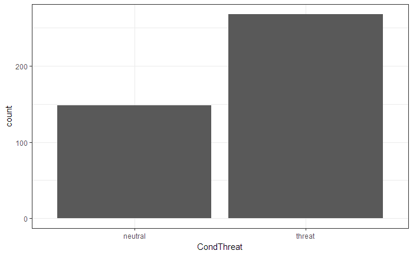

```r
affect.data %>% ggplot(aes(CondThreat)) + geom_bar()
```

#### `CondDiscomfort`

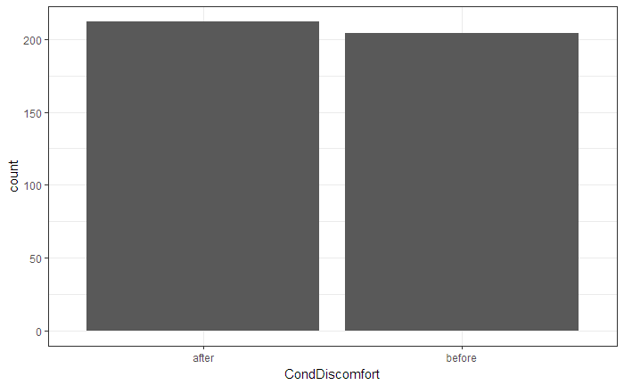

```r
affect.data %>% ggplot(aes(CondDiscomfort)) + geom_bar()
```

### Histograms

#### Negative affect

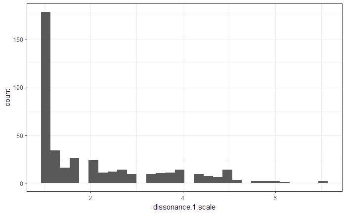

```r
affect.data %>% ggplot(aes(dissonance.1.scale)) + geom_histogram()
```

#### Issue importance

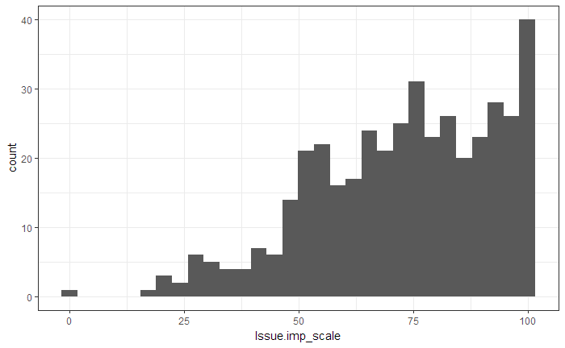

```r
affect.data %>% ggplot(aes(Issue.imp_scale)) + geom_histogram()
```

### Density estimates

You can get a better sense of the distribution of the data by using kernel density plots. Kernel density estimates take the data and “smooth” it by assuming that the data points are drawn from a population with a specific probability distribution, which implies that they have a certain statistical relationship. Based on the observed distribution of your data, it estimates the shape of the population distribution. The default is Gaussian (i.e., normal).

As you can imagine, this dosn’t work very well with small samples.

Kernel desnity estimates are computed using `density()`, but you can also plot them using `ggplot2::geom_density()`.

#### Negative affect

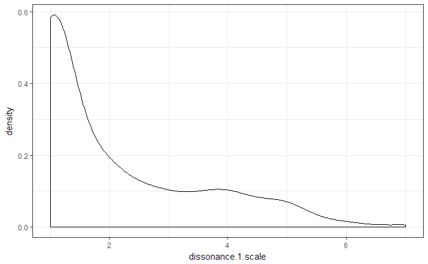

```r
affect.data %>% ggplot(aes(dissonance.1.scale)) + geom_density()
```

#### Issue importance

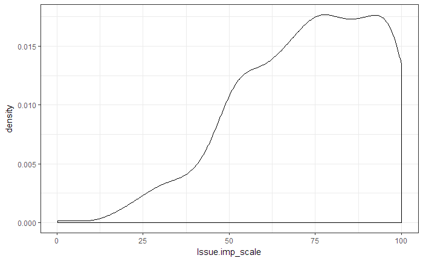

```r
affect.data %>% ggplot(aes(Issue.imp_scale)) + geom_density()
```